# Capstone Final Report

# Preparing the data for the forward defensive model:

```r
# Rename the Goals variables
hockey_data3 <- rename(hockey_data3, Goals_Against = GA.x)
hockey_data3 <- rename(hockey_data3, Future_Goals_Against = GA.y)
hockey_data3 <- rename(hockey_data3, First_Assists = `First Assists`)
hockey_data3 <- rename(hockey_data3, Second_Assists = `Second Assists`)
hockey_data3 <- rename(hockey_data3, Rush_Attempts = `Rush Attempts`)
hockey_data3 <- rename(hockey_data3, Rebounds_Created = `Rebounds Created`)
hockey_data3 <- rename(hockey_data3, Off_Zone_Starts = `Off. Zone Starts`)
hockey_data3 <- rename(hockey_data3, Neu_Zone_Starts = `Neu. Zone Starts`)
hockey_data3 <- rename(hockey_data3, Def_Zone_Starts = `Def. Zone Starts`)
hockey_data3 <- rename(hockey_data3, On_The_Fly_Starts = `On The Fly Starts`)

# Find the missing values by column
Missing_values3 <- sort(colSums(is.na(hockey_data3)), decreasing=TRUE)
Missing_values3 <- Missing_values3[Missing_values3 > 0]
print(sort(Missing_values3), decreasing=TRUE)
```

```
##                SCF%          On-Ice SH% Off. Zone Faceoff %          On-Ice SV%
##                   1                   1                   1                   2
##               HDCF%               MDCF%   Off. Zone Start %                 SH%
##                   6                   6                   8                  55
##                 GF%               HDGF%                 IPP               MDGF%
##                  73                 122                 152                 225
##               LDGF%          Faceoffs %
##                 291                1366
```

```r
# Prepare the data for the forwards 5v5 defensive model
Forward_Defensive <- hockey_data3 %>%
  filter(Position == "R"|Position == "L"|Position == "C") %>%
  dplyr::select(Player:TOI,Giveaways:Takeaways,CA,xGA,SCA,HDCA,HDGA,PDO
                ,On_The_Fly_Starts,Off_Zone_Starts:Def_Zone_Starts,
                Future_Goals_Against)

# Find the missing values by column
Missing_values3 <- sort(colSums(is.na(Forward_Defensive)), decreasing=TRUE)
Missing_values3 <- Missing_values3[Missing_values3 > 0]
print(sort(Missing_values3), decreasing=TRUE)
```

```
## named numeric(0)
```

```r
# Find the dimensions of the data
dim(Forward_Defensive)
```

```
## [1] 2291   18
```

```r
# Filtering for games played and teams played
Forward_Defensive <- hockey_data3 %>%
  filter(Position == "R"|Position == "L"|Position == "C", GP > 10) %>%
  filter(str_detect(Team, pattern=",", negate=TRUE)) %>%
  dplyr::select(Player:TOI,Giveaways:Takeaways,CA,xGA,SCA,HDCA,HDGA,PDO
                ,On_The_Fly_Starts,Off_Zone_Starts:Def_Zone_Starts,
                Future_Goals_Against)

# Find the dimensions of the data after filtering by GP and Team
dim(Forward_Defensive)
```

```
## [1] 1856   18
```

```r
head(Forward_Defensive)
```

```
##              Player Team Position GP      TOI Giveaways Takeaways  CA   xGA SCA
## 1    Aaron Volpatti  WSH        L 41 298.8667         1         6 293 10.99 133
## 2       Adam Burish  S.J        R 15 124.8000         1         2 101  3.20  38
## 3    Adam Cracknell  STL        R 19 150.8500         0         3 128  5.54  57
## 4     Adam Henrique  N.J        C 77 994.9667        21        36 742 29.62 340
## 5 Aleksander Barkov  FLA        C 54 722.1500        12        25 635 25.25 305
## 6     Alex Chiasson  DAL        R 79 846.7667        21        22 780 34.12 374
##   HDCA HDGA   PDO On_The_Fly_Starts Off_Zone_Starts Neu_Zone_Starts
## 1   53    3 0.994               220              55              93
## 2    9    2 0.911               111              22              29
## 3   20    4 1.000               146              23              35
## 4  125   16 0.994               747             171             235
## 5  116   19 0.990               535             126             176
## 6  168   27 0.967               698             173             213
##   Def_Zone_Starts Future_Goals_Against
## 1              34                    0
## 2              18                    9
## 3              10                    9
## 4             126                   35
## 5             114                   35
## 6             111                   30
```

# Analysis:

Before the defensive regression models could be made there needed to be some preprocessing. First, some variables were renamed to make them more convenient to work with. Second, It turns out that all of the variables that had missing values were not used in the analysis. Third, the data set was filtered to only included centers, left wings, and right wings, otherwise known as forwards. The full data set for forwards has the same number of observations as in the forward offensive model which includes 2291 observations. For this model there is 18 variables. In the subset of the data after filtering out players who played with more than one team in a season or played in less then 10 games, there is 1856 observations and 18 variables. After dropping unwanted variables the data set includes Player, Team, Position, GP, TOI, Giveaways, Takeaways, CA, xGA, SCA, HDCA, HDGA, PDO, On_The_Fly_Starts, Off_Zone_Starts, Neu_Zone_Starts, Def_Zone_Starts, and Future_Goals_Against. Unlike the offensive model there was no need to add one goal to the Future goals against column because no transformation was needed.

# Creating the models to predict forwards defense:

```r
# Regression analysis
# Splitting data into training and validation sets
set.seed(1)
train.rows.FD <- sample(rownames(Forward_Defensive), nrow(Forward_Defensive) * 0.7)
train.data.FD <- Forward_Defensive[train.rows.FD, ]
valid.rows.FD <- setdiff(rownames(Forward_Defensive), train.rows.FD)
valid.data.FD <- Forward_Defensive[valid.rows.FD, ]

# Create a MLR model that contains the full desired predictors
FDM_Full <- lm(Future_Goals_Against ~ Giveaways + CA + xGA + SCA +
                 HDCA + On_The_Fly_Starts + Neu_Zone_Starts
               + Def_Zone_Starts, data=train.data.FD)
# Summary
summary(FDM_Full)
```

```
##
## Call:
## lm(formula = Future_Goals_Against ~ Giveaways + CA + xGA + SCA +
##     HDCA + On_The_Fly_Starts + Neu_Zone_Starts + Def_Zone_Starts,
##     data = train.data.FD)
##
## Residuals:
##     Min      1Q  Median      3Q     Max
## -40.945  -7.810   0.059   8.040  40.287
##
## Coefficients:
##                    Estimate Std. Error t value Pr(>|t|)
## (Intercept)       11.308651   0.965527  11.712  < 2e-16 ***
## Giveaways          0.183942   0.035988   5.111 3.68e-07 ***
## CA                 0.014536   0.008937   1.626   0.1041
## xGA                0.017179   0.282471   0.061   0.9515
## SCA                0.010639   0.020179   0.527   0.5981
## HDCA               0.063721   0.038206   1.668   0.0956 .
## On_The_Fly_Starts -0.017434   0.004396  -3.966 7.72e-05 ***
## Neu_Zone_Starts    0.025045   0.010802   2.319   0.0206 *
## Def_Zone_Starts   -0.022187   0.009658  -2.297   0.0218 *
## ---
## Signif. codes:  0 '***' 0.001 '**' 0.01 '*' 0.05 '.' 0.1 ' ' 1
##
## Residual standard error: 11.59 on 1290 degrees of freedom
## Multiple R-squared:  0.3904, Adjusted R-squared:  0.3866
## F-statistic: 103.2 on 8 and 1290 DF,  p-value: < 2.2e-16
```

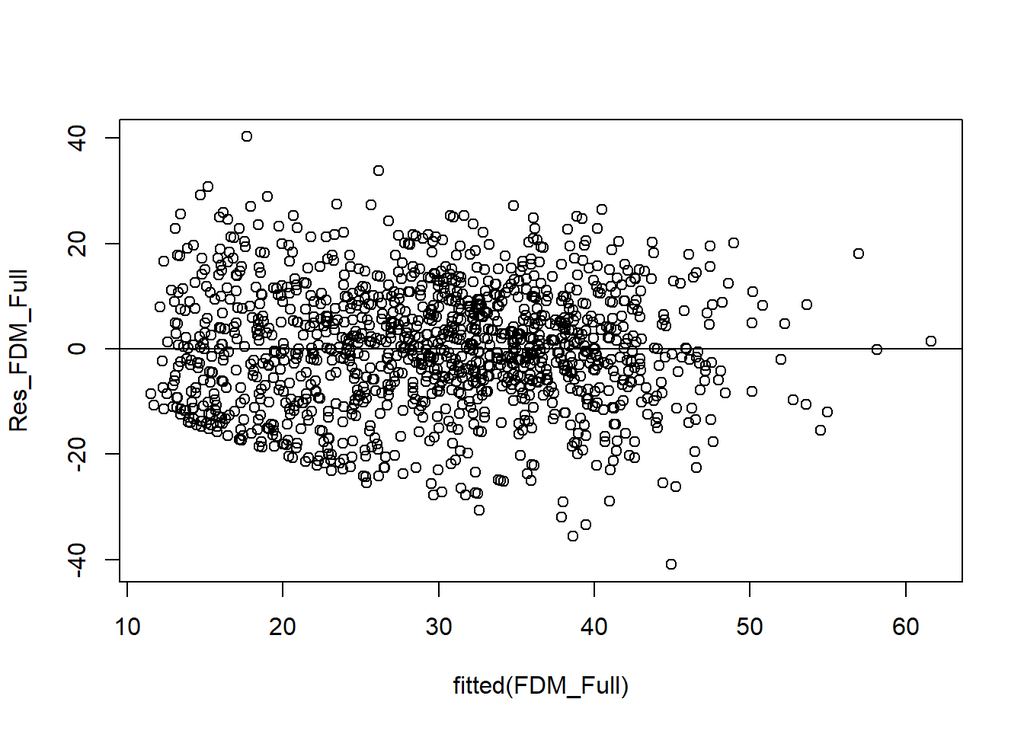

```r
# Get list of residuals
Res_FDM_Full <- resid(FDM_Full)

# Produce residual vs. fitted plot
plot(fitted(FDM_Full), Res_FDM_Full)

# Add a horizontal line at 0
abline(0,0)
```

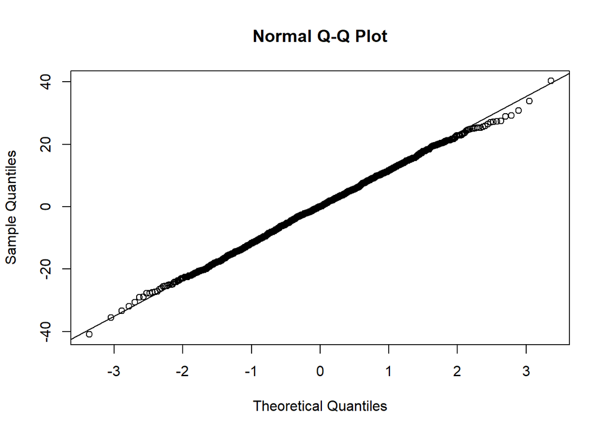

```r
# Create Q-Q plot for residuals
qqnorm(Res_FDM_Full)

# Add a straight diagonal line to the plot
qqline(Res_FDM_Full)
```

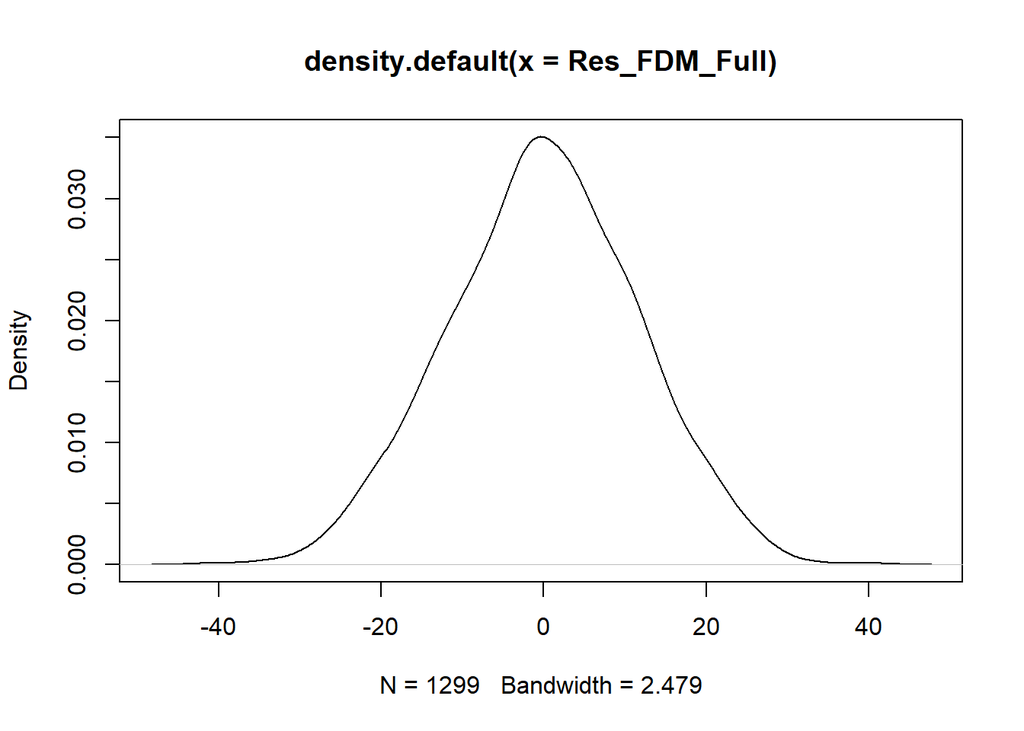

```r
# Create density plot of residuals
plot(density(Res_FDM_Full))
```

```r
# Compute VIF
vif(FDM_Full)
```

```
##         Giveaways                CA               xGA               SCA
##          2.295623         67.331201        115.814197         77.733841
##              HDCA On_The_Fly_Starts   Neu_Zone_Starts   Def_Zone_Starts
##         47.686656          8.532344          7.901274          3.056997
```

```r
# Calculate the error
accuracy(FDM_Full)
```

```
##                        ME     RMSE      MAE  MPE MAPE      MASE
## Training set 1.047895e-16 11.55016 9.216268 -Inf  Inf 0.7735437
```

```r
# Out-of-sample Prediction
pred_FDM_Full <- predict(FDM_Full, newdata=valid.data.FD)
pred_FDM_Full
```

[output not shown]

[output cut: 85 more lines]

```
## 16.22601 16.66563 30.77977 17.58208 23.47440 16.78048 33.46197 17.02079
##     1722     1723     1728     1729     1731     1732     1733     1734
## 35.17875 30.27413 39.55014 33.49700 35.44232 29.23070 43.86755 48.91449
##     1738     1739     1746     1747     1751     1752     1755     1757
## 44.87453 13.32235 40.78891 50.15208 18.65272 41.34221 24.76339 35.73992
##     1760     1763     1764     1768     1777     1778     1785     1787
## 25.95553 32.31840 33.20817 36.56874 42.04090 31.42185 27.93439 41.81788
##     1788     1790     1792     1793     1795     1796     1797     1798
## 42.05040 26.92014 37.50948 39.58742 34.19439 33.11105 13.80592 26.06954
##     1800     1801     1812     1820     1824     1825     1829     1830
## 29.89006 41.08184 22.34075 48.79122 28.14244 26.47541 35.54332 26.55996
##     1835     1836     1837     1839     1840     1842     1844     1848
## 27.68809 40.46881 35.77564 52.71367 16.99736 33.48755 36.27309 38.09359
##     1849     1851     1853     1855     1856
## 12.27208 14.33763 24.45895 38.67583 26.56134
```

```r
# Find the error of the validation data
accuracy(pred_FDM_Full, valid.data.FD$Future_Goals_Against)
```

```
##                  ME     RMSE      MAE  MPE MAPE
## Test set -0.4922936 10.97209 8.677675 -Inf  Inf
```

```r
# Best subset selection
best_subset_FDM=regsubsets(Future_Goals_Against ~ Giveaways + CA + xGA
                           + SCA + HDCA + On_The_Fly_Starts +
                             Neu_Zone_Starts + Def_Zone_Starts,
                             data=train.data.FD, nvmax=8)

# Summarize the result
best_summary_FDM=summary(best_subset_FDM)
best_summary_FDM
```

```
## Subset selection object
## Call: regsubsets.formula(Future_Goals_Against ~ Giveaways + CA + xGA +
##     SCA + HDCA + On_The_Fly_Starts + Neu_Zone_Starts + Def_Zone_Starts,
##     data = train.data.FD, nvmax = 8)
## 8 Variables  (and intercept)
##                   Forced in Forced out
## Giveaways             FALSE      FALSE
## CA                    FALSE      FALSE
## xGA                   FALSE      FALSE
## SCA                   FALSE      FALSE
## HDCA                  FALSE      FALSE
## On_The_Fly_Starts     FALSE      FALSE
## Neu_Zone_Starts       FALSE      FALSE
## Def_Zone_Starts       FALSE      FALSE
## 1 subsets of each size up to 8
## Selection Algorithm: exhaustive
##          Giveaways CA  xGA SCA HDCA On_The_Fly_Starts Neu_Zone_Starts
## 1  ( 1 ) " "       " " "*" " " " "  " "               " "
## 2  ( 1 ) "*"       " " " " " " "*"  " "               " "
## 3  ( 1 ) "*"       " " "*" " " " "  "*"               " "
## 4  ( 1 ) "*"       "*" " " " " "*"  "*"               " "
## 5  ( 1 ) "*"       "*" " " " " "*"  "*"               " "
## 6  ( 1 ) "*"       "*" " " " " "*"  "*"               "*"
## 7  ( 1 ) "*"       "*" " " "*" "*"  "*"               "*"
## 8  ( 1 ) "*"       "*" "*" "*" "*"  "*"               "*"
##          Def_Zone_Starts
## 1  ( 1 ) " "
## 2  ( 1 ) " "
## 3  ( 1 ) " "
## 4  ( 1 ) " "
## 5  ( 1 ) "*"
## 6  ( 1 ) "*"
## 7  ( 1 ) "*"
## 8  ( 1 ) "*"
```

```r
# Find the best Cp
p=2:9
Cp=cbind(p,best_summary_FDM$cp) #Pair p and Cp
colnames(Cp)=c('p','Cp') #Define column names
print(Cp)
```

```
##      p        Cp
## [1,] 2 47.222497
## [2,] 3 20.725769
## [3,] 4 13.244540
## [4,] 5  9.824475
## [5,] 6  8.814845
## [6,] 7  5.334219
## [7,] 8  7.003699
## [8,] 9  9.000000
```

```r
# Find BIC
p=2:9
BIC=cbind(p,best_summary_FDM$bic) #Pair p and BIC
colnames(BIC)=c('p','BIC') #Define column names
print(BIC)
```

```
##      p       BIC
## [1,] 2 -576.9478
## [2,] 3 -597.6545
## [3,] 4 -599.8941
## [4,] 5 -598.1343
## [5,] 6 -593.9784
## [6,] 7 -592.3148
## [7,] 8 -585.4783
## [8,] 9 -578.3126
```

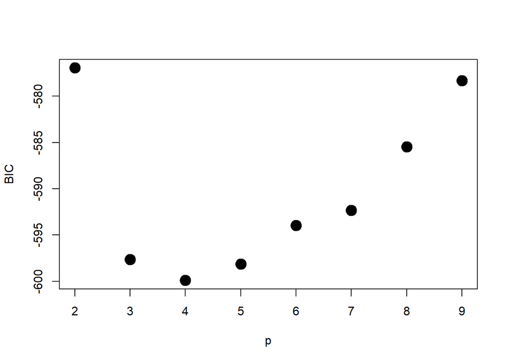

```r
plot(BIC,cex=2,pch=19) # Plot of BIC
```

```r
# Find AIC
n=nrow(train.data.FD)
p=BIC[,1]
aic=BIC[,2]-p*log(n)+2*p #Need to compute AIC using BIC
AIC=cbind(2:9,aic) #Pair p and AIC
colnames(AIC)=c('p','AIC') #Define column names
print(AIC)
```

```
##      p       AIC
## [1,] 2 -587.2865
## [2,] 3 -613.1625
## [3,] 4 -620.5715
## [4,] 5 -623.9810
## [5,] 6 -624.9945
## [6,] 7 -628.5003
## [7,] 8 -626.8331
## [8,] 9 -624.8368
```

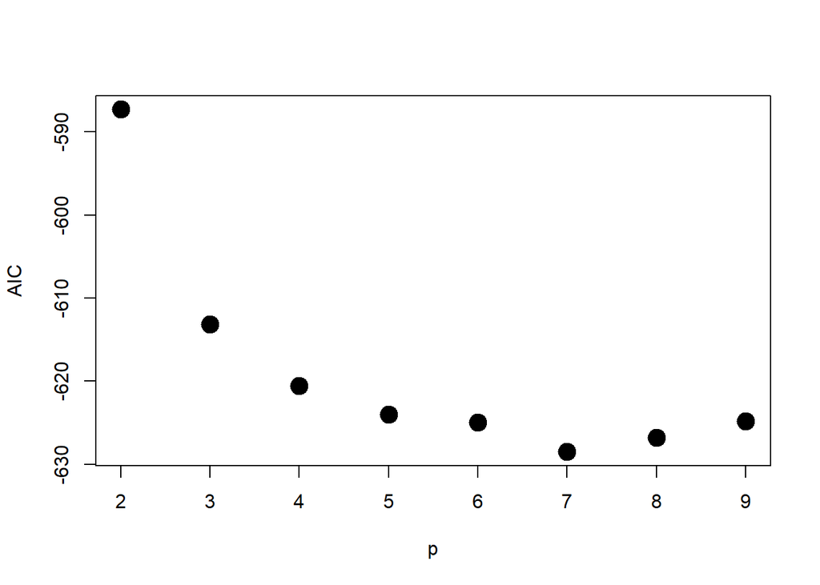

```r
plot(AIC,cex=2,pch=19) #Plot of AIC
```

```r
# Best Cp Model
FDM_BestCp <- lm(Future_Goals_Against ~ Giveaways + CA + HDCA +
                   On_The_Fly_Starts + Neu_Zone_Starts +
                   Def_Zone_Starts,data=train.data.FD)
# Summary
summary(FDM_BestCp)
```

```
##
## Call:
## lm(formula = Future_Goals_Against ~ Giveaways + CA + HDCA + On_The_Fly_Starts +
##     Neu_Zone_Starts + Def_Zone_Starts, data = train.data.FD)
##
## Residuals:
##     Min      1Q  Median      3Q     Max
## -40.927  -7.823  -0.020   7.984  40.282
##
## Coefficients:
##                    Estimate Std. Error t value Pr(>|t|)
## (Intercept)       11.276662   0.962629  11.714  < 2e-16 ***
## Giveaways          0.186183   0.035686   5.217 2.11e-07 ***
## CA                 0.017987   0.005835   3.082 0.002097 **
## HDCA               0.076326   0.021496   3.551 0.000398 ***
## On_The_Fly_Starts -0.017695   0.004369  -4.050 5.42e-05 ***
## Neu_Zone_Starts    0.025226   0.010768   2.343 0.019302 *
## Def_Zone_Starts   -0.022804   0.009561  -2.385 0.017222 *
## ---
## Signif. codes:  0 '***' 0.001 '**' 0.01 '*' 0.05 '.' 0.1 ' ' 1
##
## Residual standard error: 11.58 on 1292 degrees of freedom
## Multiple R-squared:  0.3902, Adjusted R-squared:  0.3874
## F-statistic: 137.8 on 6 and 1292 DF,  p-value: < 2.2e-16
```

```r
# Compute VIF
vif(FDM_BestCp)
```

```
##         Giveaways                CA              HDCA On_The_Fly_Starts
##          2.260175         28.741902         15.115083          8.438750
##   Neu_Zone_Starts   Def_Zone_Starts
##          7.863112          3.000070
```

```r
# Calculate the error
accuracy(FDM_BestCp)
```

```
##                        ME     RMSE      MAE  MPE MAPE      MASE
## Training set 6.273236e-16 11.55165 9.218659 -Inf  Inf 0.7737444
```

```r
# Out-of-sample Prediction
pred_FDM_BestCp <- predict(FDM_BestCp, newdata = valid.data.FD)
pred_FDM_BestCp
```

[output not shown]

[output cut: 85 more lines]

```
## 16.30629 16.69656 30.88182 17.52954 23.38468 16.70127 33.40857 17.00271
##     1722     1723     1728     1729     1731     1732     1733     1734
## 35.22611 30.31126 39.51342 34.21133 35.58619 29.88722 43.95836 49.04890
##     1738     1739     1746     1747     1751     1752     1755     1757
## 45.00789 13.37416 40.63338 50.11513 18.78120 41.42772 24.58689 35.92265
##     1760     1763     1764     1768     1777     1778     1785     1787
## 26.05452 32.44314 33.37456 36.87418 41.76969 31.33101 27.97752 41.86674
##     1788     1790     1792     1793     1795     1796     1797     1798
## 42.06778 26.79697 37.73058 39.66481 33.68247 33.48628 13.71456 26.10529
##     1800     1801     1812     1820     1824     1825     1829     1830
## 29.69113 41.24860 22.26051 48.93552 28.27904 26.43800 35.44623 26.88393
##     1835     1836     1837     1839     1840     1842     1844     1848
## 27.72076 40.58610 36.01739 52.65794 17.07618 33.11515 36.28267 37.92935
##     1849     1851     1853     1855     1856
## 12.21168 14.27435 24.61909 38.60808 26.88524
```

```r
# Find the error of the validation data
accuracy(pred_FDM_BestCp, valid.data.FD$Future_Goals_Against)
```

```
##                  ME     RMSE      MAE  MPE MAPE
## Test set -0.5047672 10.96308 8.674125 -Inf  Inf
```

```r
# Best BIC Model
FDM_BestBIC <- lm(Future_Goals_Against ~ Giveaways + xGA +
                    On_The_Fly_Starts,data=train.data.FD)

# Summary
summary(FDM_BestBIC)
```

```
##
## Call:
## lm(formula = Future_Goals_Against ~ Giveaways + xGA + On_The_Fly_Starts,
##     data = train.data.FD)
##
## Residuals:
##     Min      1Q  Median      3Q     Max
## -39.879  -7.536   0.106   8.126  40.912
##
## Coefficients:
##                    Estimate Std. Error t value Pr(>|t|)
## (Intercept)       11.214727   0.965463  11.616  < 2e-16 ***
## Giveaways          0.194051   0.035290   5.499  4.6e-08 ***
## xGA                0.762304   0.068399  11.145  < 2e-16 ***
## On_The_Fly_Starts -0.011927   0.003702  -3.221  0.00131 **
## ---
## Signif. codes:  0 '***' 0.001 '**' 0.01 '*' 0.05 '.' 0.1 ' ' 1
##
## Residual standard error: 11.63 on 1295 degrees of freedom
## Multiple R-squared:  0.3836, Adjusted R-squared:  0.3822
## F-statistic: 268.7 on 3 and 1295 DF,  p-value: < 2.2e-16
```

```r
# Compute VIF
vif(FDM_BestBIC)
```

```
##         Giveaways               xGA On_The_Fly_Starts
##          2.191807          6.742465          6.008991
```

```r
# Calculate the error
accuracy(FDM_BestBIC)
```

```
##                         ME     RMSE      MAE  MPE MAPE      MASE
## Training set -2.250617e-16 11.61375 9.274064 -Inf  Inf 0.7783947
```

```r
# Out-of-sample Prediction
pred_FDM_BestBIC <- predict(FDM_BestBIC, newdata=valid.data.FD)
pred_FDM_BestBIC
```

[output not shown]

[output cut: 85 more lines]

```
## 15.56540 16.63369 31.04666 18.51304 24.71697 15.88584 33.29594 16.34048
##     1722     1723     1728     1729     1731     1732     1733     1734
## 35.12121 30.23953 39.82963 30.93270 34.06589 26.43645 41.90626 48.92895
##     1738     1739     1746     1747     1751     1752     1755     1757
## 46.34821 13.32380 41.55141 48.45883 17.77818 42.61349 22.95164 36.02241
##     1760     1763     1764     1768     1777     1778     1785     1787
## 25.54400 31.48508 32.62054 37.84276 41.38403 28.73848 25.85820 43.55167
##     1788     1790     1792     1793     1795     1796     1797     1798
## 42.86318 27.31848 40.47111 38.22916 35.08545 34.11584 13.82250 26.62045
##     1800     1801     1812     1820     1824     1825     1829     1830
## 29.74408 41.52008 22.24622 46.00601 28.67127 28.44914 37.01744 25.67615
##     1835     1836     1837     1839     1840     1842     1844     1848
## 26.77416 39.79480 35.45059 56.45980 16.69698 35.71705 37.06009 37.30790
##     1849     1851     1853     1855     1856
## 12.58332 14.70363 23.14083 36.99706 28.29963
```

```r
# Find the error of the validation data
accuracy(pred_FDM_BestBIC, valid.data.FD$Future_Goals_Against)
```

```
##                  ME     RMSE     MAE  MPE MAPE
## Test set -0.5105188 11.04359 8.72648 -Inf  Inf
```

```r
# Best AIC Model
FDM_BestAIC <- lm(Future_Goals_Against ~ Giveaways + CA + HDCA +
                    On_The_Fly_Starts + Neu_Zone_Starts +
                    Def_Zone_Starts, data=train.data.FD)

# Summary
summary(FDM_BestAIC)
```

```
##
## Call:
## lm(formula = Future_Goals_Against ~ Giveaways + CA + HDCA + On_The_Fly_Starts +
##     Neu_Zone_Starts + Def_Zone_Starts, data = train.data.FD)
##
## Residuals:
##     Min      1Q  Median      3Q     Max
## -40.927  -7.823  -0.020   7.984  40.282
##
## Coefficients:
##                    Estimate Std. Error t value Pr(>|t|)
## (Intercept)       11.276662   0.962629  11.714  < 2e-16 ***
## Giveaways          0.186183   0.035686   5.217 2.11e-07 ***
## CA                 0.017987   0.005835   3.082 0.002097 **
## HDCA               0.076326   0.021496   3.551 0.000398 ***
## On_The_Fly_Starts -0.017695   0.004369  -4.050 5.42e-05 ***
## Neu_Zone_Starts    0.025226   0.010768   2.343 0.019302 *
## Def_Zone_Starts   -0.022804   0.009561  -2.385 0.017222 *
## ---
## Signif. codes:  0 '***' 0.001 '**' 0.01 '*' 0.05 '.' 0.1 ' ' 1
##
## Residual standard error: 11.58 on 1292 degrees of freedom
## Multiple R-squared:  0.3902, Adjusted R-squared:  0.3874
## F-statistic: 137.8 on 6 and 1292 DF,  p-value: < 2.2e-16
```

```r
# Compute VIF
vif(FDM_BestAIC)
```

```
##         Giveaways                CA              HDCA On_The_Fly_Starts
##          2.260175         28.741902         15.115083          8.438750
##   Neu_Zone_Starts   Def_Zone_Starts
##          7.863112          3.000070
```

```r
# Calculate the error
accuracy(FDM_BestAIC)
```

```
##                        ME     RMSE      MAE  MPE MAPE      MASE
## Training set 6.273236e-16 11.55165 9.218659 -Inf  Inf 0.7737444
```

```r
# Out-of-sample Prediction
pred_FDM_BestAIC <- predict(FDM_BestAIC, newdata = valid.data.FD)
pred_FDM_BestAIC
```

[output not shown]

[output cut: 85 more lines]

```
## 16.30629 16.69656 30.88182 17.52954 23.38468 16.70127 33.40857 17.00271
##     1722     1723     1728     1729     1731     1732     1733     1734
## 35.22611 30.31126 39.51342 34.21133 35.58619 29.88722 43.95836 49.04890
##     1738     1739     1746     1747     1751     1752     1755     1757
## 45.00789 13.37416 40.63338 50.11513 18.78120 41.42772 24.58689 35.92265
##     1760     1763     1764     1768     1777     1778     1785     1787
## 26.05452 32.44314 33.37456 36.87418 41.76969 31.33101 27.97752 41.86674
##     1788     1790     1792     1793     1795     1796     1797     1798
## 42.06778 26.79697 37.73058 39.66481 33.68247 33.48628 13.71456 26.10529
##     1800     1801     1812     1820     1824     1825     1829     1830
## 29.69113 41.24860 22.26051 48.93552 28.27904 26.43800 35.44623 26.88393
##     1835     1836     1837     1839     1840     1842     1844     1848
## 27.72076 40.58610 36.01739 52.65794 17.07618 33.11515 36.28267 37.92935
##     1849     1851     1853     1855     1856
## 12.21168 14.27435 24.61909 38.60808 26.88524
```

```r
# Find the error of the validation data
accuracy(pred_FDM_BestAIC, valid.data.FD$Future_Goals_Against)
```

```
##                  ME     RMSE      MAE  MPE MAPE
## Test set -0.5047672 10.96308 8.674125 -Inf  Inf
```

# Analysis:

Like the forward models I created a range of different regression models to predict the future goals against for the forwards in the NHL. First, I separated the data into the training and validation sets with 70% of the data in the training set and 30% in the later. I then ran the full regression model with the variables Giveaways, CA, xGA, SCA, HDCA, On_The_Fly_Starts, Neu_Zone_Starts, and Def_Zone_Starts. This model had a worse adjusted r-square value then the forward offensive model but better than the forward defensive models. I found this surprising since there is so much that a player cannot control like his line mates, goalie, and the coaches decisions so I thought the model would be worse. Unlike before, the residuals were fine so no transformation was needed. I then ran the best subset model to find the Cp, BIC, and AIC models. After looking at the VIF values I found that the only model without multicollinearity being the BIC model. Because of this I chose the BIC model as my best model to predict forwards future goals against. The BIC model had 3 predictors and they are all significant. Since this model did not need a transformation there was no need to adjust the prediction and error calculation.

# Picking the model:

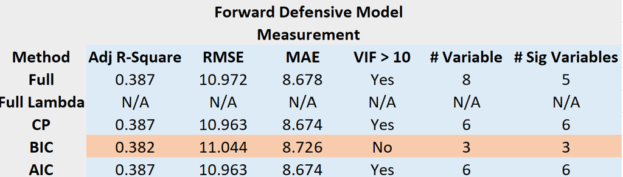

```r
# Error table
knitr::include_graphics("C:/Users/nickg/OneDrive/Desktop/Capstone/FDM_Error_Table.png")
```

# Analysis:

I really did not have much of a choice when picking the model because the BIC model is the only one that does not have multicollinearity. This model has the highest RMSE and MAE but also has the smallest number of predictors. This is definitely not ideal but the good news is the variables in the model make sense from a logical perspective. There are only three predictors in this model which are giveaways, XGA otherwise known as the probability of an opponents shot becoming a goal, and on the fly starts. It makes sense that the number of giveaways and the better the quality chances would be good predictors of future goals against. As for the on the fly starts it appears to have the same effect as previous models where it is negatively correlated. Overall this model seems to be okay given the amount of uncertainty that comes with a players defense.

# Preparing the data for the defense defensive model:

# Analysis:

The preprocessing for the defensemen defensive model was almost the exact same as for the forward defensive model with the only difference being the data was filtered for defensemen. Like the other defensemen models there were 1047 observations.

# Creating the models to predict defensemen defense:

```r
# Regression analysis
# Splitting data into training and validation sets
set.seed(1)
train.rows.DD <- sample(rownames(Defense_Defensive), nrow(Defense_Defensive) * 0.7)
train.data.DD <- Defense_Defensive[train.rows.DD, ]
valid.rows.DD <- setdiff(rownames(Defense_Defensive), train.rows.DD)
valid.data.DD <- Defense_Defensive[valid.rows.DD, ]

# Create a MLR model that contains the full desired predictors
DDM_Full <- lm(Future_Goals_Against ~ Giveaways + CA + xGA + SCA +
                 HDCA + On_The_Fly_Starts + Neu_Zone_Starts
               + Def_Zone_Starts, data=train.data.DD)
# Summary
summary(DDM_Full)
```

```
##
## Call:
## lm(formula = Future_Goals_Against ~ Giveaways + CA + xGA + SCA +
##     HDCA + On_The_Fly_Starts + Neu_Zone_Starts + Def_Zone_Starts,
##     data = train.data.DD)
##
## Residuals:
##     Min      1Q  Median      3Q     Max
## -48.330  -9.655   0.529   9.491  46.615
##
## Coefficients:
##                     Estimate Std. Error t value Pr(>|t|)
## (Intercept)       11.7012502  1.5660719   7.472 2.29e-13 ***
## Giveaways          0.1591103  0.0469817   3.387 0.000746 ***
## CA                 0.0057030  0.0112781   0.506 0.613241
## xGA                0.8887706  0.3911706   2.272 0.023375 *
## SCA               -0.0496274  0.0271336  -1.829 0.067811 .
## HDCA               0.0211610  0.0561107   0.377 0.706188
## On_The_Fly_Starts -0.0145472  0.0050625  -2.874 0.004178 **
## Neu_Zone_Starts    0.0496085  0.0173062   2.867 0.004271 **
## Def_Zone_Starts   -0.0003311  0.0237127  -0.014 0.988863
## ---
## Signif. codes:  0 '***' 0.001 '**' 0.01 '*' 0.05 '.' 0.1 ' ' 1
##
## Residual standard error: 14.15 on 723 degrees of freedom
## Multiple R-squared:  0.3996, Adjusted R-squared:  0.3929
## F-statistic: 60.14 on 8 and 723 DF,  p-value: < 2.2e-16
```

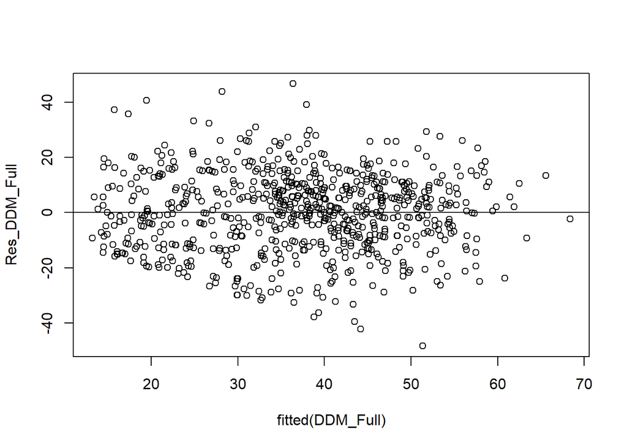

```r
# Get list of residuals
Res_DDM_Full <- resid(DDM_Full)

# Produce residual vs. fitted plot
plot(fitted(DDM_Full), Res_DDM_Full)

# Add a horizontal line at 0
abline(0,0)
```

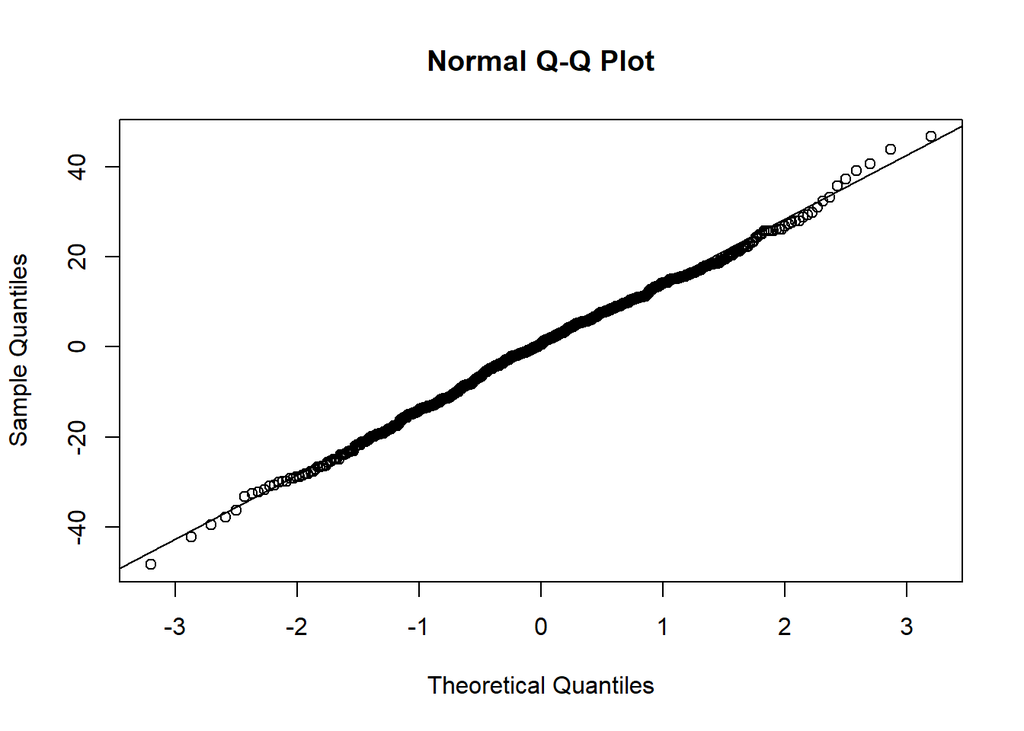

```r
# Create Q-Q plot for residuals
qqnorm(Res_DDM_Full)

# Add a straight diagonal line to the plot
qqline(Res_DDM_Full)
```

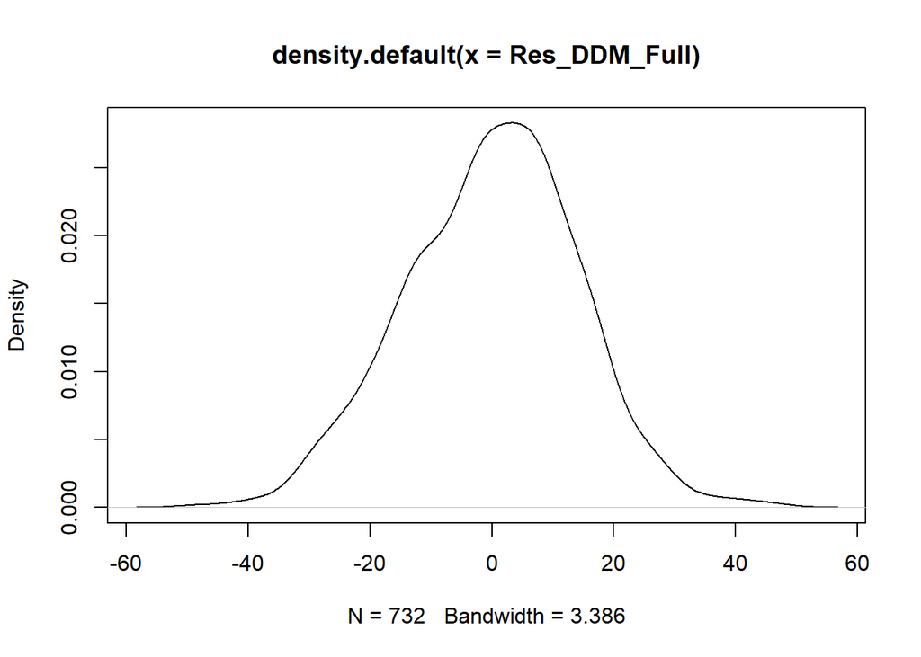

```r
# Create density plot of residuals
plot(density(Res_DDM_Full))
```

```r
# Compute VIF
vif(DDM_Full)
```

```
##         Giveaways                CA               xGA               SCA
##          2.324188         61.281879        119.433853         74.928290
##              HDCA On_The_Fly_Starts   Neu_Zone_Starts   Def_Zone_Starts
##         55.406227          6.801246         10.561927          8.451542
```

```r
# Calculate the error
accuracy(DDM_Full)
```

```
##                        ME    RMSE      MAE  MPE MAPE      MASE
## Training set 6.744093e-16 14.0634 11.19521 -Inf  Inf 0.7623235
```

```r
# Out-of-sample Prediction
pred_DDM_Full <- predict(DDM_Full, newdata=valid.data.DD)
pred_DDM_Full
```

[output not shown]

[output cut: 25 more lines]

```
## 35.45869 42.90852 15.54575 29.63871 28.17243 37.09616 15.18544 36.10742
##      875      877      880      886      888      890      895      896
## 27.39534 48.05106 38.16798 40.39750 36.60823 51.01352 18.19439 30.15086
##      897      900      904      907      910      915      916      923
## 27.00228 51.28383 31.84377 27.96561 43.66262 43.80118 31.80584 34.98897
##      926      927      928      934      937      938      940      942
## 27.21357 56.82893 49.24140 12.84489 46.04078 22.08692 26.34420 39.17925
##      944      947      949      951      955      956      957      960
## 67.51283 17.19372 15.76393 49.90376 37.15736 33.57979 53.31611 56.78265
##      963      965      970      971      978      986      991      998
## 28.80414 50.16632 30.33847 25.76060 48.92121 36.73677 34.63214 42.38286
##      999     1008     1013     1014     1026     1029     1031     1033
## 56.37475 64.64490 45.33723 21.83097 43.26823 25.61639 28.48759 29.76411
##     1038     1046     1047
## 45.06909 57.26115 44.35957
```

```r
# Find the error of the validation data
accuracy(pred_DDM_Full, valid.data.DD$Future_Goals_Against)
```

```
##                ME     RMSE      MAE  MPE MAPE
## Test set 1.061157 14.82376 11.65851 -Inf  Inf
```

```r
# Best subset selection
best_subset_DDM=regsubsets(Future_Goals_Against ~ Giveaways + CA + xGA
                           + SCA + HDCA + On_The_Fly_Starts +
                             Neu_Zone_Starts + Def_Zone_Starts,
                           data=train.data.DD, nvmax=8)

# Summarize the result
best_summary_DDM=summary(best_subset_DDM)
best_summary_DDM
```

```
## Subset selection object
## Call: regsubsets.formula(Future_Goals_Against ~ Giveaways + CA + xGA +
##     SCA + HDCA + On_The_Fly_Starts + Neu_Zone_Starts + Def_Zone_Starts,
##     data = train.data.DD, nvmax = 8)
## 8 Variables  (and intercept)
##                   Forced in Forced out
## Giveaways             FALSE      FALSE
## CA                    FALSE      FALSE
## xGA                   FALSE      FALSE
## SCA                   FALSE      FALSE
## HDCA                  FALSE      FALSE
## On_The_Fly_Starts     FALSE      FALSE
## Neu_Zone_Starts       FALSE      FALSE
## Def_Zone_Starts       FALSE      FALSE
## 1 subsets of each size up to 8
## Selection Algorithm: exhaustive
##          Giveaways CA  xGA SCA HDCA On_The_Fly_Starts Neu_Zone_Starts
## 1  ( 1 ) " "       " " "*" " " " "  " "               " "
## 2  ( 1 ) "*"       " " "*" " " " "  " "               " "
## 3  ( 1 ) "*"       " " "*" " " " "  " "               "*"
## 4  ( 1 ) "*"       " " "*" " " " "  "*"               "*"
## 5  ( 1 ) "*"       " " "*" "*" " "  "*"               "*"
## 6  ( 1 ) "*"       "*" "*" "*" " "  "*"               "*"
## 7  ( 1 ) "*"       "*" "*" "*" "*"  "*"               "*"
## 8  ( 1 ) "*"       "*" "*" "*" "*"  "*"               "*"
##          Def_Zone_Starts
## 1  ( 1 ) " "
## 2  ( 1 ) " "
## 3  ( 1 ) " "
## 4  ( 1 ) " "
## 5  ( 1 ) " "
## 6  ( 1 ) " "
## 7  ( 1 ) " "
## 8  ( 1 ) "*"
```

```r
# Find the best Cp
p=2:9
Cp=cbind(p,best_summary_DDM$cp) #Pair p and Cp
colnames(Cp)=c('p','Cp') #Define column names
print(Cp)
```

```
##      p        Cp
## [1,] 2 26.486315
## [2,] 3 18.472123
## [3,] 4 11.519151
## [4,] 5  4.604627
## [5,] 6  3.307937
## [6,] 7  5.142674
## [7,] 8  7.000195
## [8,] 9  9.000000
```

```r
# Find BIC
p=2:9
BIC=cbind(p,best_summary_DDM$bic) #Pair p and BIC
colnames(BIC)=c('p','BIC') #Define column names
print(BIC)
```

```
##      p       BIC
## [1,] 2 -328.9885
## [2,] 3 -332.1735
## [3,] 4 -334.4341
## [4,] 5 -336.7644
## [5,] 6 -333.4973
## [6,] 7 -327.0688
## [7,] 8 -320.6173
## [8,] 9 -314.0217
```

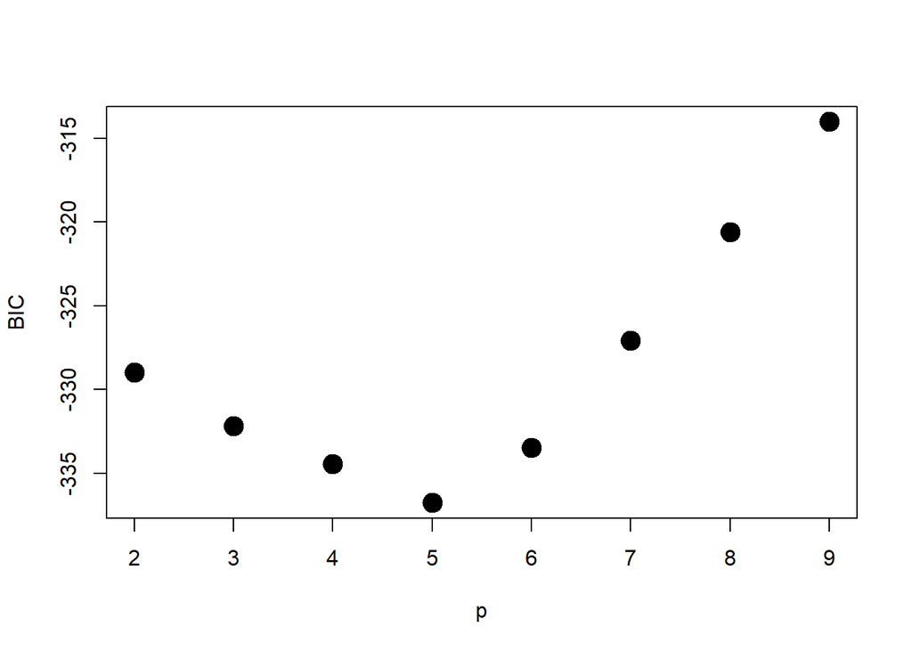

```r
plot(BIC,cex=2,pch=19) # Plot of BIC
```

```r
# Find AIC
n=nrow(train.data.DD)
p=BIC[,1]
aic=BIC[,2]-p*log(n)+2*p #Need to compute AIC using BIC
AIC=cbind(2:9,aic) #Pair p and AIC
colnames(AIC)=c('p','AIC') #Define column names
print(AIC)
```

```
##      p       AIC
## [1,] 2 -338.1801
## [2,] 3 -345.9608
## [3,] 4 -352.8172
## [4,] 5 -359.7433
## [5,] 6 -361.0720
## [6,] 7 -359.2393
## [7,] 8 -357.3835
## [8,] 9 -355.3837
```

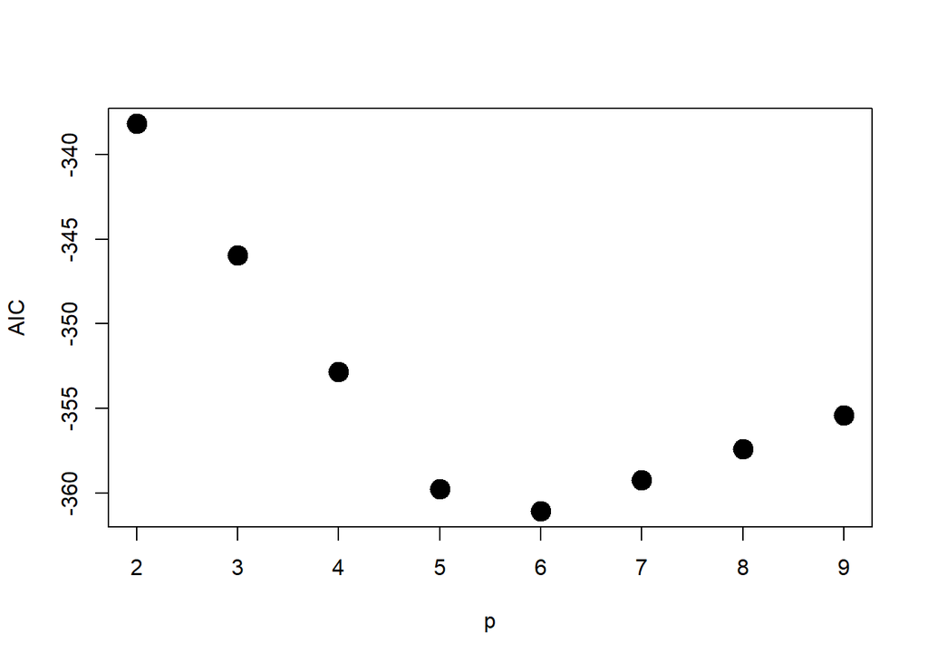

```r
plot(AIC,cex=2,pch=19) #Plot of AIC
```

```r
# Best Cp Model
DDM_BestCp <- lm(Future_Goals_Against ~ Giveaways + CA + xGA + SCA +
                On_The_Fly_Starts + Neu_Zone_Starts,data=train.data.DD)

# Summary
summary(DDM_BestCp)
```

```
##
## Call:
## lm(formula = Future_Goals_Against ~ Giveaways + CA + xGA + SCA +
##     On_The_Fly_Starts + Neu_Zone_Starts, data = train.data.DD)
##
## Residuals:
##     Min      1Q  Median      3Q     Max
## -48.205  -9.537   0.507   9.464  46.353
##
## Coefficients:
##                    Estimate Std. Error t value Pr(>|t|)
## (Intercept)       11.705746   1.561788   7.495 1.94e-13 ***
## Giveaways          0.159794   0.046517   3.435 0.000626 ***
## CA                 0.004236   0.010407   0.407 0.684094
## xGA                0.994117   0.273859   3.630 0.000303 ***
## SCA               -0.046689   0.025961  -1.798 0.072526 .
## On_The_Fly_Starts -0.014644   0.005044  -2.903 0.003808 **
## Neu_Zone_Starts    0.049001   0.013848   3.538 0.000428 ***
## ---
## Signif. codes:  0 '***' 0.001 '**' 0.01 '*' 0.05 '.' 0.1 ' ' 1
##
## Residual standard error: 14.13 on 725 degrees of freedom
## Multiple R-squared:  0.3994, Adjusted R-squared:  0.3945
## F-statistic: 80.37 on 6 and 725 DF,  p-value: < 2.2e-16
```

```r
# Compute VIF
vif(DDM_BestCp)
```

```
##         Giveaways                CA               xGA               SCA
##          2.284286         52.315681         58.690024         68.768776
## On_The_Fly_Starts   Neu_Zone_Starts
##          6.769891          6.780270
```

```r
# Calculate the error
accuracy(DDM_BestCp)
```

```
##                         ME     RMSE      MAE  MPE MAPE      MASE
## Training set -2.447412e-16 14.06479 11.19598 -Inf  Inf 0.7623756
```

```r
# Out-of-sample Prediction
pred_DDM_BestCp <- predict(DDM_BestCp, newdata=valid.data.DD)
pred_DDM_BestCp
```

[output not shown]

[output cut: 25 more lines]

```
## 35.46852 42.38519 15.47009 29.87107 27.99294 36.80532 15.18526 36.01688
##      875      877      880      886      888      890      895      896
## 27.36521 48.59879 38.11243 40.25445 36.51123 51.29449 18.13525 30.35919
##      897      900      904      907      910      915      916      923
## 26.78111 51.69296 31.88782 28.17586 43.87284 43.74959 31.53245 34.72594
##      926      927      928      934      937      938      940      942
## 27.26574 57.14951 49.86474 12.88166 46.27458 22.15983 26.19120 38.70104
##      944      947      949      951      955      956      957      960
## 67.62150 17.23403 15.73708 49.84126 37.33031 33.37718 53.32234 56.74254
##      963      965      970      971      978      986      991      998
## 28.87852 50.54017 30.28495 25.93451 49.01786 36.71295 34.38116 42.21325
##      999     1008     1013     1014     1026     1029     1031     1033
## 56.14592 64.96738 45.38466 21.87355 43.49868 25.63895 28.59830 29.78360
##     1038     1046     1047
## 44.82911 57.26143 44.19901
```

```r
# Find the error of the validation data
accuracy(pred_DDM_BestCp, valid.data.DD$Future_Goals_Against)
```

```
##                ME     RMSE      MAE  MPE MAPE
## Test set 1.051705 14.82413 11.65914 -Inf  Inf
```

```r
# Best BIC Model
DDM_BestBIC <- lm(Future_Goals_Against ~ Giveaways + xGA + On_The_Fly_Starts +
                  Neu_Zone_Starts,data=train.data.DD)

# Summary
summary(DDM_BestBIC)
```

```
##
## Call:
## lm(formula = Future_Goals_Against ~ Giveaways + xGA + On_The_Fly_Starts +
##     Neu_Zone_Starts, data = train.data.DD)
##
## Residuals:
##     Min      1Q  Median      3Q     Max
## -46.537  -9.591   0.667   9.285  45.979
##
## Coefficients:
##                    Estimate Std. Error t value Pr(>|t|)
## (Intercept)       11.559940   1.560816   7.406 3.61e-13 ***
## Giveaways          0.153630   0.046294   3.319 0.000950 ***
## xGA                0.577631   0.105492   5.476 6.01e-08 ***
## On_The_Fly_Starts -0.014459   0.004841  -2.987 0.002916 **
## Neu_Zone_Starts    0.048040   0.012739   3.771 0.000176 ***
## ---
## Signif. codes:  0 '***' 0.001 '**' 0.01 '*' 0.05 '.' 0.1 ' ' 1
##
## Residual standard error: 14.15 on 727 degrees of freedom
## Multiple R-squared:  0.3966, Adjusted R-squared:  0.3932
## F-statistic: 119.4 on 4 and 727 DF,  p-value: < 2.2e-16
```

```r
# Compute VIF
vif(DDM_BestBIC)
```

```
##         Giveaways               xGA On_The_Fly_Starts   Neu_Zone_Starts
##          2.257861          8.691052          6.223711          5.726226
```

```r
# Calculate the error
accuracy(DDM_BestBIC)
```

```
##                         ME     RMSE     MAE  MPE MAPE      MASE
## Training set -6.168959e-16 14.09842 11.2136 -Inf  Inf 0.7635757
```

```r
# Out-of-sample Prediction
pred_DDM_BestBIC <- predict(DDM_BestBIC, newdata=valid.data.DD)
pred_DDM_BestBIC
```

[output not shown]

[output cut: 25 more lines]

```
## 35.45705 42.49611 15.51483 30.79539 26.67994 37.89661 14.92304 35.85117
##      875      877      880      886      888      890      895      896
## 26.88061 48.38256 38.77895 42.39083 36.06665 50.57617 18.07073 32.58039
##      897      900      904      907      910      915      916      923
## 26.81358 51.63657 30.22824 27.29036 44.18272 43.85427 31.78560 35.19762
##      926      927      928      934      937      938      940      942
## 26.47029 57.95674 49.91287 12.79502 46.07442 21.55750 25.60962 39.50093
##      944      947      949      951      955      956      957      960
## 65.49766 16.89568 15.74769 51.27228 36.27198 33.31582 54.32850 54.09198
##      963      965      970      971      978      986      991      998
## 29.55110 49.61969 29.90947 26.13559 49.84363 36.90685 34.23340 44.25281
##      999     1008     1013     1014     1026     1029     1031     1033
## 55.22270 63.58627 45.49418 21.26225 45.48576 25.70357 28.08989 28.98455
##     1038     1046     1047
## 44.35217 57.91198 44.94707
```

```r
# Find the error of the validation data
accuracy(pred_DDM_BestBIC, valid.data.DD$Future_Goals_Against)
```

```
##                ME     RMSE      MAE  MPE MAPE
## Test set 1.023986 14.80172 11.66088 -Inf  Inf
```

```r
# Best AIC Model
DDM_BestAIC <- lm(Future_Goals_Against ~ Giveaways + xGA + SCA +
                    On_The_Fly_Starts + Neu_Zone_Starts,
                    data=train.data.DD)

# Summary
summary(DDM_BestAIC)
```

```
##
## Call:
## lm(formula = Future_Goals_Against ~ Giveaways + xGA + SCA + On_The_Fly_Starts +
##     Neu_Zone_Starts, data = train.data.DD)
##
## Residuals:
##     Min      1Q  Median      3Q     Max
## -48.027  -9.540   0.494   9.460  46.456
##
## Coefficients:
##                    Estimate Std. Error t value Pr(>|t|)
## (Intercept)       11.715770   1.560696   7.507 1.78e-13 ***
## Giveaways          0.158009   0.046283   3.414 0.000676 ***
## xGA                1.021093   0.265567   3.845 0.000131 ***
## SCA               -0.041768   0.022962  -1.819 0.069315 .
## On_The_Fly_Starts -0.014067   0.004839  -2.907 0.003756 **
## Neu_Zone_Starts    0.051114   0.012831   3.984 7.47e-05 ***
## ---
## Signif. codes:  0 '***' 0.001 '**' 0.01 '*' 0.05 '.' 0.1 ' ' 1
##
## Residual standard error: 14.12 on 726 degrees of freedom
## Multiple R-squared:  0.3993, Adjusted R-squared:  0.3952
## F-statistic: 96.52 on 5 and 726 DF,  p-value: < 2.2e-16
```

```r
# Compute VIF
vif(DDM_BestAIC)
```

```
##         Giveaways               xGA               SCA On_The_Fly_Starts
##          2.263984         55.252921         53.857377          6.236065
##   Neu_Zone_Starts
##          5.827352
```

```r
# Calculate the error
accuracy(DDM_BestAIC)
```

```
##                        ME    RMSE      MAE  MPE MAPE      MASE
## Training set 5.114709e-18 14.0664 11.19562 -Inf  Inf 0.7623515
```

```r
# Out-of-sample Prediction
pred_DDM_BestAIC <- predict(DDM_BestAIC, newdata=valid.data.DD)
pred_DDM_BestAIC
```

[output not shown]

[output cut: 25 more lines]

```
## 35.76412 42.48150 15.50980 29.65225 27.87980 36.95811 15.16841 36.21993
##      875      877      880      886      888      890      895      896
## 27.35055 48.83333 38.25068 40.53392 36.44761 51.17381 18.23613 30.40165
##      897      900      904      907      910      915      916      923
## 26.85225 51.77131 32.01310 27.93819 44.02589 43.77202 31.26746 34.59740
##      926      927      928      934      937      938      940      942
## 27.32360 57.31183 50.24699 12.87834 45.86480 22.08988 26.08626 38.84776
##      944      947      949      951      955      956      957      960
## 67.40453 17.21603 15.72077 49.91122 37.27693 33.53257 53.10963 56.65346
##      963      965      970      971      978      986      991      998
## 28.85715 50.37395 30.47806 26.00339 49.23557 36.89459 34.18672 42.38984
##      999     1008     1013     1014     1026     1029     1031     1033
## 56.12217 65.36120 44.42643 21.83478 43.63289 25.75163 28.67485 29.73515
##     1038     1046     1047
## 44.77027 57.83049 44.15356
```

```r
# Find the error of the validation data
accuracy(pred_DDM_BestAIC, valid.data.DD$Future_Goals_Against)
```

```
##                ME     RMSE      MAE  MPE MAPE
## Test set 1.045506 14.83549 11.67721 -Inf  Inf
```